# TP 2 : transfert thermique ou onde le long d'une plaque

Le notebook ci-après permet de résoudre par discrétisation l'équation de la chaleur $\frac{\partial T}{\partial t} = \frac{\partial^2 T}{\partial x^2}+\frac{\partial^2 T}{\partial y^2}$ le long d'une plaque de 10 cm x 10 cm initialement à $T= 0°C$ sur toute sa surface, chauffée à $T=100°C$ en son milieu au temps $t=0$, et maintenue pour tout temps $t$ à $T=0°C$ sur ses bords.

Q1- Reproduisez ce notebook pour une température au centre de $x_0 °C$ et pour un maillage d'une plaque de $x_1$cm * $x_1$cm en $x_1^2$ éléments et réaliser sous [gif.imageonline](https://gif.imageonline.co/fr/) une animation graphique de l'évolution de la température au fil du temps.

Q2- Indiquez à $10^{-6}$ près la durée au bout de laquelle le centre sera à la température $x_0/2$ °C.

Q3- Réalisez une résolution par discrétisation de l'équation d'onde le long de la même plaque : $\frac{\partial^2 T}{\partial t^2} = \frac{\partial^2 T}{\partial x^2}+\frac{\partial^2 T}{\partial y^2}$ si l'on suppose que cette plaque est initialement immobile sauf en son milieu où l'on impose en $x_1$ ms un déplacement transversal $Y=1 mm$ puis réaliser une animation graphique de la propagation de cette onde comme pour la Question 1.

Q4- Indiquer à $10^{-6}$ près la valeur du déplacement transversal Y au bout de $x_0/2$ ms.

**Déposez l'ensemble de votre notebook imprimé au format pdf sous SAVOIR, avec des liens vers vos 2 animations comme dans l'exemple ci-après.**

## Exemple de résolution dans le cas de la plaque sus-évoquée

```python
from sympy import *
init_printing()
```

```python
import matplotlib.pyplot as plt
import numpy as np
```

```python
# Pas de temps et d'espace (en s et en cm)
h,k=1/400,1/5
```

#### Initialisation des températures

```python
n=0
T = np.zeros((11,11)) # On crée une matrice 11x11 avec des zéros
T[5,5]=100  # On change juste la valeur en (5,5)
```

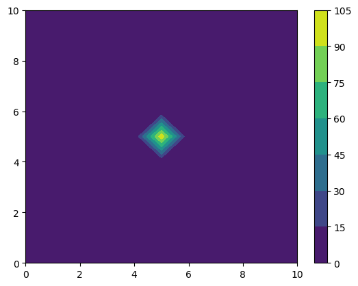

```python
# Initialisation des températures (100°C au centre de la plaque et à 0°C ailleurs)
cont=plt.contourf(T); plt.colorbar(cont);
plt.savefig('Im_profils_temper/fig'+str(n)+'.png') # On a créé un répertoire Im_profils_temper et on y sauve l'image n°0
listeT55=[T[5,5]] # On initialise une liste avec la valeur de T au centre, c'est à dire au noeud (5,5)
```

#### Calcul des températures suivantes sur 5 incréments de temps

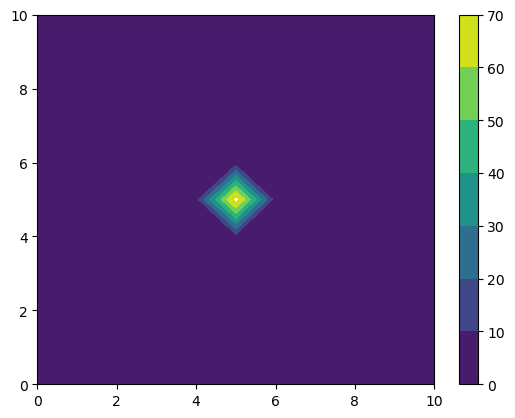

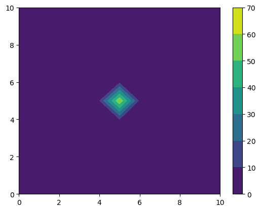

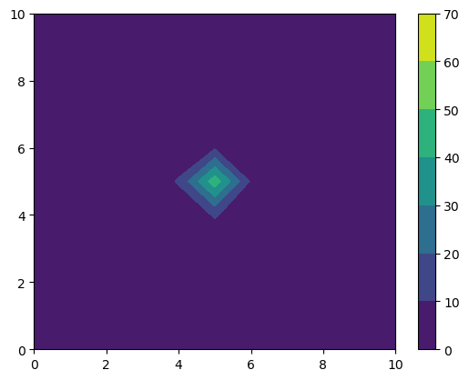

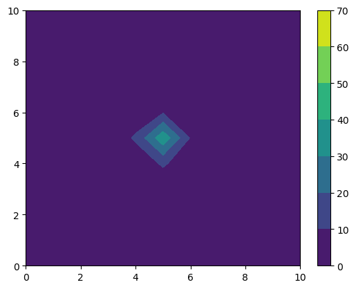

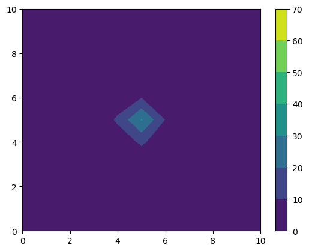

```python
levels=np.linspace(0,70,8) #On subdivise en 7 intervalles (avec 8 bornes) le domaine de température ([0;70°C])

for n in range(1,6): #Pour 5 intervalles de temps

    # On calcule la température en chaque noeud (i,j) en fonction de celle à l'instant précédent
    for i in range(1,10):
        for j in range(1,10):
            T[i,j]=T[i,j] + h/k**2 * (T[i-1,j]+T[i+1,j]+T[i,j-1]+T[i,j+1]-4*T[i,j]) # Nouveau T[i,j] en fonction de l'ancien

    #On trace un graphique en contours
    cont=plt.contourf(np.array(T),levels=levels);plt.colorbar(cont);
    plt.savefig('Im_profils_temper/fig'+str(n)+'.png')
    plt.show()

    # On récupère à chaque itération la température au noeud (5,5)
    listeT55.append(T[5,5])
```

On peut enregistrer l'animation en transférant ces images de votre répertoire vers **gif.imageonline**, ce qui conduit à l'animation suivante (obtenue avec **clic droit\copier le lien** sur le bouton **télécharger GIF**): [Anim.gif](https://drive.google.com/file/d/1oHAMZTe52hlXET4Nk1kayaF9nq0ifGPU/view?usp=sharing)

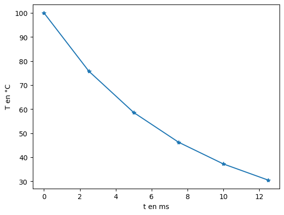

```python
# Evolution de la température T au centre (noeud 5,5)
tt= [i*h*1E3 for i in range(6)]
plt.plot(tt,listeT55,'-*')
plt.xlabel('t en ms')
plt.ylabel('T en °C')
plt.show()
```